# R Notebook

# 1 - Introduction - About R Notebooks

This is an [R Markdown](http://rmarkdown.rstudio.com) Notebook. When you execute code within the notebook, the results appear beneath the code. In R Markdown documents, code is embedded in chunks, marked off by three back ticks and then the designation {r}. You can add additional detail about the chunk after the ‘r’, i.e. setup, information about the calculation, etc. You can also specify if you want the code itself to be included in any output document (the ‘echo’ option), and if you want any displayed results to be included (the ‘eval’ option). By default both options are set to true, so both code and output will be included in any output. We will use code chunks throughout this document for examples, and you will also create your own code chunks.

## How to run a code chunk

To execute a code chunk, click the *Run* button within the chunk (green arrow in the top right), or put your cursor inside the code chunk grey window and press *Cmd+Shift+Enter*.

## Document organization using Markdown

You’ll also notice that sections are marked off by hashmarks - #. This provides formatting when publishing this document as a PDF, slideshow, etc. It also allows for navigation via the navigation bar at the bottom of this document window. You can navigate throughout the document using the menu.

## Saving and previewing the notebook

When you save the notebook, an HTML file containing the code and output will be saved alongside it. Click the *Preview* button or press *Cmd+Shift+K* to preview the HTML file - this will appear in the right hand side window in the *Viewer* tab. The preview shows you a rendered HTML copy of the contents of the editor. Consequently, unlike *Knit*, *Preview* does not run any R code chunks. Instead, the output of the chunk when it was last run in the editor is displayed.

# 2 - Setup

This set of commands downlaods, installs and attaches packages we will need for this lesson. If you get a message asking to restart R, click Yes. If you get asked to recompile anything from a source binary, type Yes in the console. Run the code in this code chunk by following the directions given in the *Introduction - How to run a code chunk* section.

```r
# You can include comments in code chunks by using a hash at the beginning of the line.
# For this chunk, I set eval=F so you don't get all the package loading messages cluttering up your HTML output.

install.packages("tidyverse")
install.packages("caTools")
install.packages("bitops")
install.packages("PeriodicTable")
install.packages("ggplot2")
library("tidyverse")
library("caTools")
library("bitops")
library("PeriodicTable")
library("ggplot2")
```

We will be working with a dataset from the **PeriodicTable: Periodic Table of the Elements package by Julien Idé**. Information and documentation about this dataset can be found here: https://cran.r-project.org/package=PeriodicTable.

Run the code chunk below to load this dataset into the R environment.

```r
data("periodicTable")
```

You should now see “periodicTable” in the Environment tab on the right side of your RStudio window.

# 3 - Simple Scatter Plot

There’s lots of data that we can play with here. Let’s start by making a simple plot of atomic mass versus atomic number to check the integrity of our data. What should this plot look like? Run the code below to generate a graph.

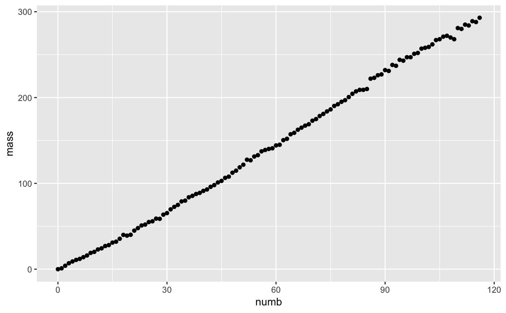

```r
ggplot(data=periodicTable, aes(x=numb,y=mass)) + geom_point()
```

This is an example of the most basic of ggplots. It has three key elements:

1. “data=”: the data you are plotting (usually the name of your data frame in your environment)
2. “aes()”: these are the aesthetic mappings for the plot - how are we visually representing the data variables. The basic ones used here are:
- what data to plot on the x axis (x=vector_in_dataframe)
- what data to plot on the y axis (y=vector_in_dataframe)
3. An additional layer (signified by the + symbol) to describe what the plotted data should look like using the geom designation.

In this case, we are using the periodicTable dataframe, and plotting numb on x and mass on y. We are specifiying the data be represented as individual points.

## Exercise 3.1 - Finding A Pattern

Add a new chunk below by clicking the *Insert Chunk* button (top of the window on the toolbar) or by pressing *Cmd+Option+I*. Make a scatter plot of density (y axis) versus atomic mass (x axis). Plot the data as points.

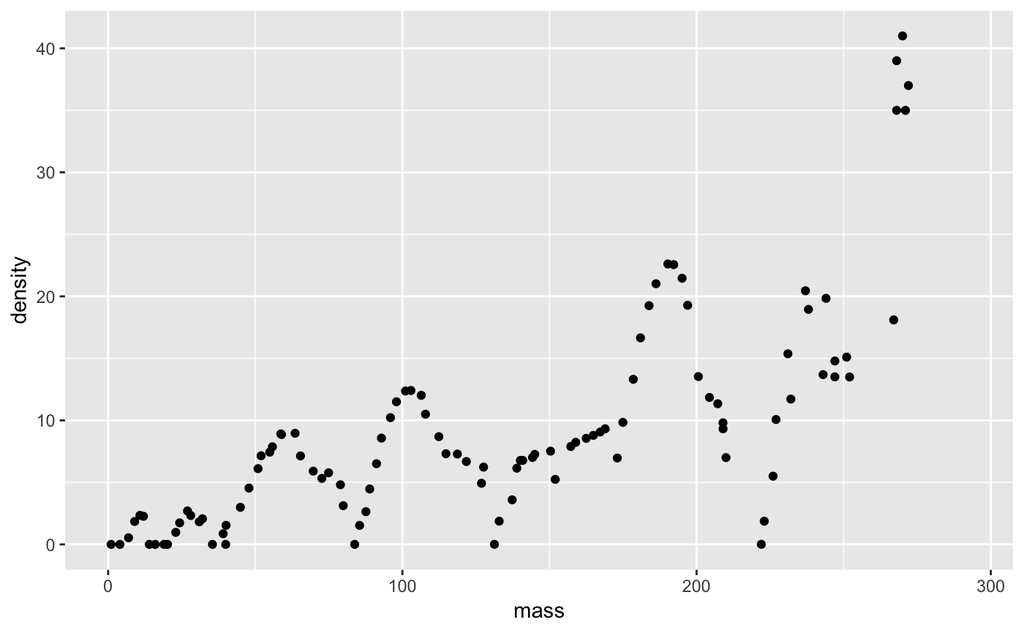

```r
ggplot(data=periodicTable,aes(x=mass,y=density)) + geom_point()
```

## Exercise 3.2 - geom_point options

There are many options and aesthetics that you can add to a simple scatter plot using geom_point. An extensive overview can be found in the https://ggplot2.tidyverse.org/reference/geom_point.html.

Let’s replot our density graph with the following three additions to the geom_point layer:

1. Change the colour to red: colour = “red”
2. Change the shape to triangles: shape = “triangle”
3. Remove the missing values: na.rm = TRUE

Add a new chunk below by clicking the *Insert Chunk* button (top of the window on the toolbar) or by pressing *Cmd+Option+I*. Replot your expression from Exercise 1 and add the above options to the geom_point() layer, separating each option by a comma.

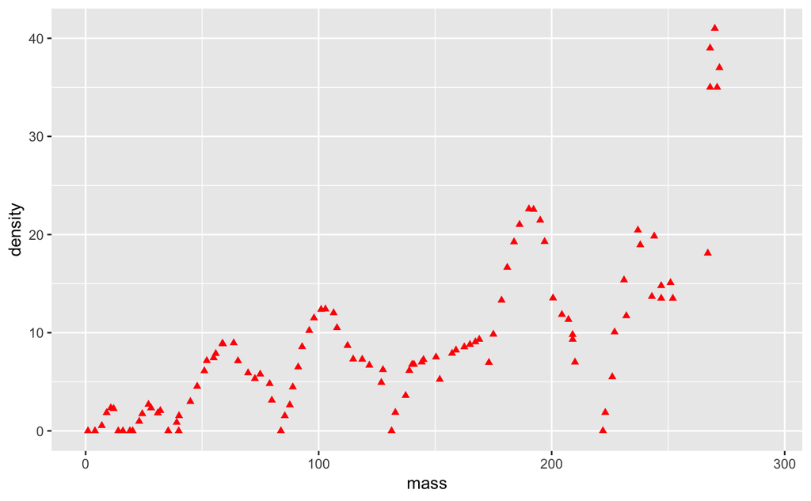

```r
ggplot(data=periodicTable,aes(x=mass,y=density)) + geom_point(colour="red",shape="triangle",na.rm=TRUE)
```

## Exercise 3.3 - Using colour to elucidate patterns

We can see from the previous plots some of the periodicity behind the periodic table :) We’ve seen that we can change the color of an entire plot. Can we use colour to further pick out the changes from the table by colouring the points according to what period they are in? We can do this by specifying an additional aesthetic in the main data layer using “aes()”.

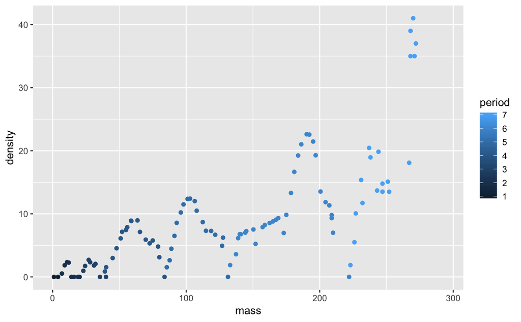

```r
# Remove this for the learner version.
ggplot(data=periodicTable,aes(x=mass,y=density,color=period)) + geom_point()
```

## Exercise 3.4 - Adding Color by Factor

Our previous plot shows us the variation, but it would be more accurate to have the periods as discrete colors and not a gradient. The reason it plotted period as a gradient is because in the data frame, period is an integer. ggplot treats number and integer vectors as continuous variables by default - hence it uses a gradient color scheme. In this case, we want period to be a categorical value, or a factor. This can be done by changing color=period to color=factor(period).

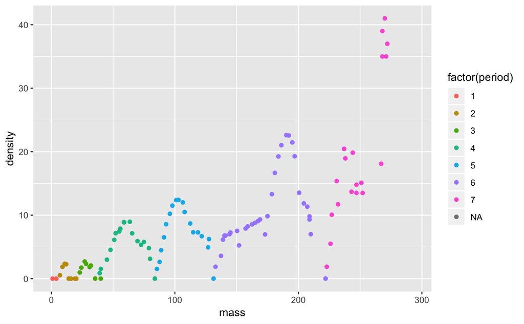

```r
# Remove this for the learner version.
ggplot(data=periodicTable,aes(x=mass,y=density,color=factor(period))) + geom_point()
```

Alternately, to get the same effect, you can change the data type for that column directly in the data frame. You can do that with the following command (you don’t need to run this):

```r
periodicTable$period <- factor(periodicTable$period)
```

Then, when you add color=period, ggplot will automatically plot it as a factor.

However, if you’re not sure you want to permanently change a data type, just modify it in the ggplot expression.

You can change the type back to numberic with the following (also, you don’t need to run this):

```r
periodicTable$period <- as.numeric(periodicTable$period)
```

It’s tricker to change it back to the original integer type, but more information on that can be found here: https://stackoverflow.com/questions/3418128/how-to-convert-a-factor-to-integer-numeric-without-loss-of-information

# 4 - Adding a Fit

Let’s go back to our original graph of mass versus numb from the beginning of Section 3 (the plot_for_data_integrity chunk, if you are using the navigation menu at the bottom):

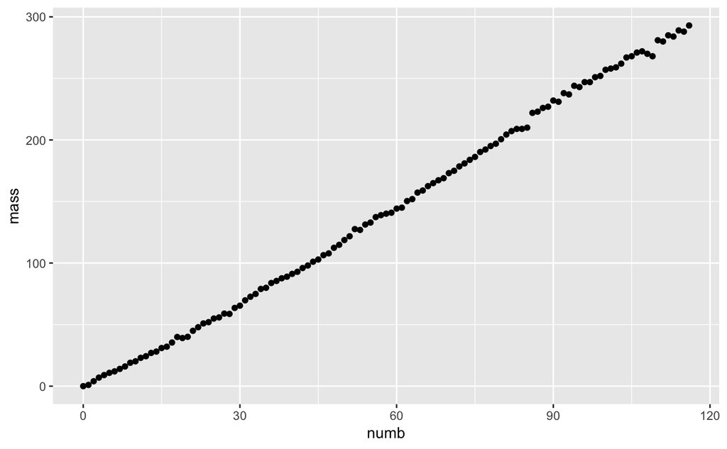

```r
ggplot(data=periodicTable,aes(x=numb,y=mass)) + geom_point()
```

We would like to add a linear fit to this graph. We can do this by adding a layer of geom_smooth() and specifying the model we want to use. There are many options that can be used for a fit - more info on geom_smooth() can be found here: https://ggplot2.tidyverse.org/reference/geom_smooth.html.

## Exercise 4.1 - Adding a linear fit

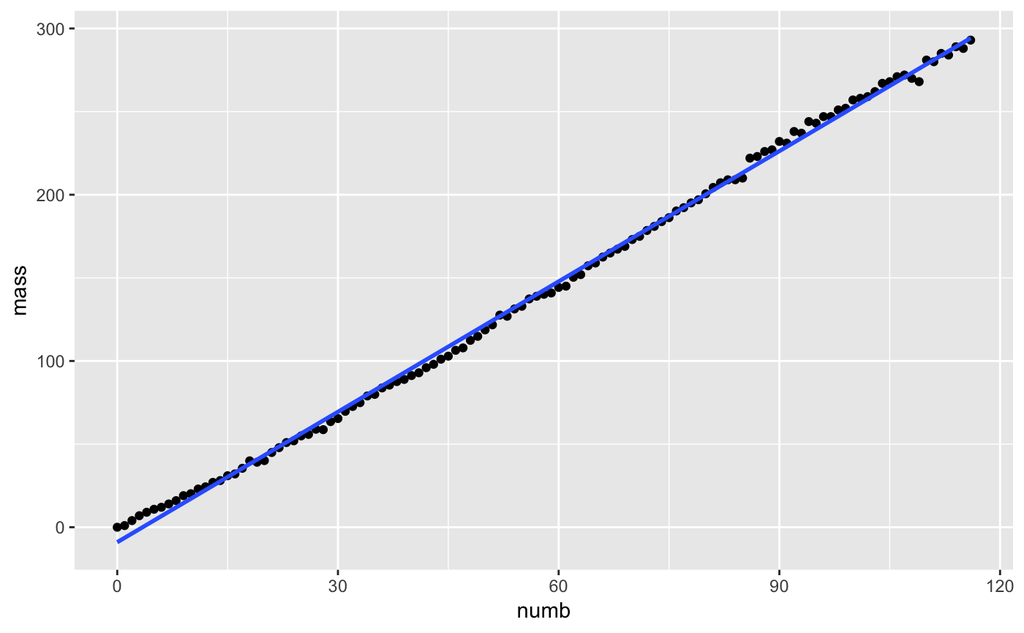

```r
ggplot(data=periodicTable,aes(x=numb,y=mass)) + geom_point() + geom_smooth(method="lm")
```

## Exercise 4.2 - Adding linear fit parameters to the plot

It might be useful to display the parameters, like slope and intercept, of the fitted line on the graph. How can we do that? Although the plot is calculated by ggplot, we need to do the calculation for the fit parameters outside of ggplot in order to get the exact numbers. Then we can add them to the plot.

The following code runs a simple linear model approximation on our data (“lm”), stores it in an object called ‘mass_correlation’, and displays the slope and intercept values of the line we generated above. Run the code below. Do the numbers make sense?

```r
mass_correlation <- lm(mass ~ numb, data=periodicTable)
coef(summary(mass_correlation))
```

```
             Estimate  Std. Error   t value      Pr(>|t|)
(Intercept) -9.004058 0.666401668 -13.51146  1.714181e-25
numb         2.613775 0.009928983 263.24703 9.504291e-162
```

We can pull out the specific correlation values using the following indices - run the code below to assign these values to objects called intercept and slope:

```r
intercept <- mass_correlation$coefficients[1]
slope <- mass_correlation$coefficients[2]
intercept
```

```
(Intercept)
  -9.004058
```

```r
slope
```

```
    numb
2.613775
```

Since we are focusing on plotting here and not on statistics, let’s figure out how to get this on our plot. Believe it or not this is not as straightforward as one might think. Text is added to plots using an annotate() layer. More info on annotate() can be found here: https://ggplot2.tidyverse.org/reference/annotate.html. The options for annotate() include the type of annotation (in this case “text”), the position on the graph (x and y), and the value (this can be a reference to a value in a vector, dataframe or list).

Run the code below to show how to add a text annotation for the intercept value to the plot:

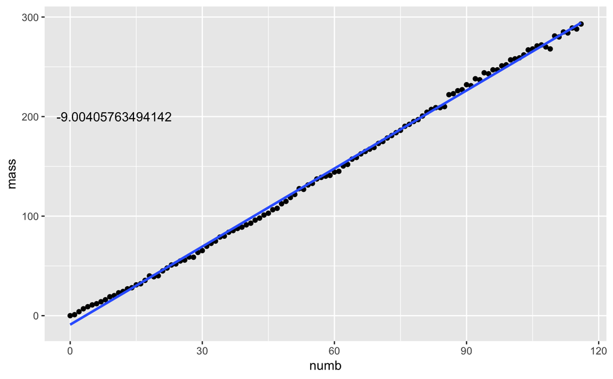

```r
ggplot(data=periodicTable,aes(x=numb,y=mass)) + geom_point() + geom_smooth(method="lm") + annotate("text", x=10, y=200, label=intercept)
```

Let’s add the slope value to the graph now. Add a new chunk by clicking the *Insert Chunk* button (top of the window on the toolbar) or by pressing *Cmd+Option+I*. Copy the code from the add_annotation chunk above and add a second annotate() layer to add the value for the slope. You may need to adjust your x and y values!

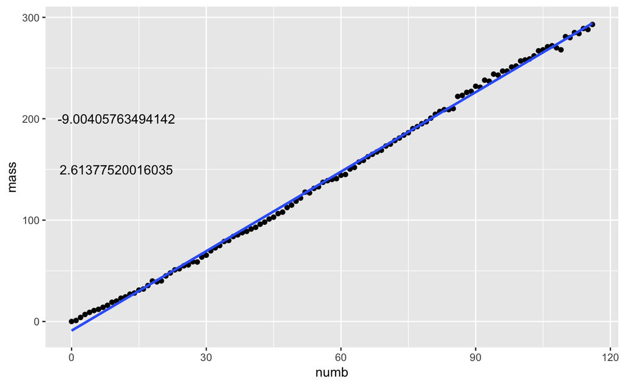

```r
# Remove this for the learner version.
ggplot(data=periodicTable,aes(x=numb,y=mass)) + geom_point() + geom_smooth(method="lm") + annotate("text", x=10, y=200, label=intercept) + annotate("text", x=10, y=150, label=slope)
```